# Overview

Now it's time to learn a bit more about the ideas and principles underlying good visualizations.

- First you will watch some videos on visualization. There are 2 videos, one with a general overview, then we get more specifc.
- After that, we'll be reading about *scientific data visualization*, and the huge number of things you can do with just one variable. Naturally, we'll be answering questions about that book.
- And finally reproducing some of those the plots from that book.

## Part 1: Fundamentals of data visualization

Find your headphones and get an intro to data visualization.

```python
# Intro video
from IPython.display import YouTubeVideo
YouTubeVideo("9D2aI30AMhM",width=800,height=450)
```

[video not shown]

Next, something a bit more specific on data analysis. Digging a bit more into the theory.

```python
YouTubeVideo("yiU56codNlI",width=800, height=450)
```

[video not shown]

> *Excercise:* Questions for the lecture
> - As mentioned earlier, visualization is not the only way to test for correlation. We can (for example) calculate the Pearson correlation. Explain in your own words how the Pearson correlation works and write down it's mathematical formulation. Can you think of an example where it fails (and visualization works)?
> - **ANS:** Pearson Correlation finds out coefficient which lets us know how one variable is related to another variable.

$$ Corr_{X,Y} = {\dfrac{cov(X,Y)} {\sigma_X\sigma_Y}} $$

- {cov} is the covariance
- ${\sigma _{X}}$ is the standard deviation of X
- ${\sigma _{Y}}$ is the standard deviation of Y

When there is no direct relation between two variables then pearson correlation fails and simple scatter plot might give better insights. Pearson correlation also does not work when there are lot of outliers as it can skew correlation coefficient.

> - What is the difference between a bar-chart and a histogram?
> - **ANS:** Bar chart represents quantity of each individual value of variable whereas histogram combines few variable quantities into one bin representing range of values.
> - I mention in the video that it's important to choose the right bin-size in histograms. But how do you do that? Do a Google search to find a criterion you like and explain it.
> - **ANS:** The Freedman-Diaconis rule is very robust and works well in practice. The bin-width is set to $h=2×IQR×n^{−1/3}$. So the number of bins is $(max−min)/h$, where n is the number of observations, max is the maximum value and min is the minimum value and IQR is inter quartile range.

## Part 2: Reading about the theory of visualization

Since we can go deeper with the visualization this year, we are going to read the first couple of chapters from [*Data Analysis with Open Source Tools*](http://shop.oreilly.com/product/9780596802363.do). It's pretty old, but I think it's a fantastic ressource and one that is pretty much as relevant now as it was back then. The author is a physicist (like me) so I like the way he thinks. And the books takes the reader all the way from visualization, through modeling to computational mining. Anywho - it's a great book and well worth reading in its entirety.

As part of this class we'll be reading the first two chapters. Today, we'll read chaper 2 (28 pages) which supports and deepens many of the points I made during the first lecture (second video above). You can get the text [here](https://cn.inside.dtu.dk/cnnet/filesharing/download/f79eb11c-2ecc-449a-94e5-4d13b5792986).

> *Excercise*: Questions for DAOST
> - Explain in your own words the point of the jitter plot.
> - **ANS:** Jitter plot is like line plot where each point is plotted on single line with it values but also adding random values to each values so that same values does not overlap on one-another.
> - Explain in your own words the point of figure 2-3. (I'm going to skip saying "in your own words" going forward, but I hope you get the point; I expect all answers to be in your own words).
> - **ANS:** Bin width and alignment of bin on x-axis also plays important role in determining histogram representation. Bin width with very large can hide actual event. Figure 2-3 shows 2 figures both have same bin width but different alignment of x-axis. First figure in 2-3 is aligned with integer numbers hence data seems flat. Second figure on the other hand starts at 0.5 and shows distribution differently.also shows peak in between which reflects normal distribution.
> - The author of DAOST (Philipp Janert) likes KDEs (and think they're better than histograms). And I don't. I didn't give a detailed explanation in the video, but now that works to my advantage. I'll ask you guys to think about this and thereby create an excellent exercise: When can KDEs be misleading? (I'll provide the answer in a later lecture :)
> - **ANS:** Kernel density plots work well when you're comparing a few distributions on a single panel, when histograms are at best confusing and at worst useless. If the sample size is small they will still be "shoogly", thus giving some indication of uncertainty.
> - I've discussed some strengths of the CDF - there are also weaknesses. Janert writes "CDFs have less intuitive appeal than histograms of KDEs". What does he mean by that?
> - **ANS:** CDF lets us know distribution of data more accurately than that of KDEs and Histograms. From graph 2-7, we can see that KDE shows that majority of events occurred at t=3 whereas looking at CDF we get idea that almost 40% events are occurred between 0-500 seconds. CDFs are less wiggly than a histogram (or KDE) but contain the same information in a representation that is inherently less noisy
> - What is a *Quantile plot*? What is it good for.
> - **ANS:** Quantile plot is same as CDF with x and y axis reversed. Quantile plots help easily decide which values falls into which quantile range.
> - How is a *Probablity plot* defined? What is it useful for? Have you ever seen one before?
> - **ANS:** in probability plot, data are plotted against a theoretical distribution in such a way that the points should form approximately a straight line. Departures from this straight line indicate departures from the specified distribution. It's useful in assessing whether dataset follows any distribution like normal or weibull or not.
> - One of the reasons I like DAOST is that Janert is so suspicious of mean, median, and related summary statistics. Explain why one has to be careful when using those - and why visualization of the full data is always better.
> - **ANS:** Different datasets can have same mean, median and other statistics. In that case mean, median, corr does not give meaningful insights. Visualizing data in those scenarios can give proper insights. It's also explained above with anscombe's quartet where mean, median and corr fails to give meaningful insights but data visualization does gives meaningful insights.
> - I love box plots. When are box plots most useful?
> - **ANS:** It is particularly useful for quickly summarizing and comparing different sets of results from different experiments
> - The book doesn't mention [violin plots](https://en.wikipedia.org/wiki/Violin_plot). Are those better or worse than box plots? Why?
> - **ANS:** A violin plot is more informative than a plain box plot. While a box plot only shows summary statistics such as mean/median and interquartile ranges, the violin plot shows the full distribution of the data

## Part 3: *Finally*! Let's create some visualizations

> *Excercise*: Connecting the dots and recreating plots from DAOST but using our own favorite dataset.
> - Let's make a jitter-plot (that is, code up something like **Figure 2-1** from DAOST from scratch), but based on SF Police data. My hunch from inspecting the file is that the police-folks might be a little bit lazy in noting down the **exact** time down to the second. So choose a crime-type and a suitable time interval (somewhere between a month and 6 months depending on the crime-type) and create a jitter plot of the arrest times during a single hour (like 13-14, for example). So let time run on the $x$-axis and create vertical jitter.

```python
import seaborn as sns
import pandas as pd
import matplotlib.pyplot as plt
import numpy as np
import scipy

%matplotlib inline

## Loading Data from https://data.sfgov.org/Public-Safety/Police-Department-Incident-Reports-2018-to-Present/wg3w-h783
sf_police_df = pd.read_csv('Police_Department_Incident_Reports__Historical_2003_to_May_2018.csv')
sf_police_df.head()
```

|  | IncidntNum | Category | Descript | DayOfWeek | Date | Time | PdDistrict | Resolution | Address | X | Y | Location | PdId |
| --- | --- | --- | --- | --- | --- | --- | --- | --- | --- | --- | --- | --- | --- |
| 0 | 110308742 | MISSING PERSON | FOUND PERSON | Friday | 04/15/2011 | 16:00 | TARAVAL | LOCATED | 0 Block of CRESPI DR | -122.476328 | 37.719687 | POINT (-122.476327815126 37.7196874952717) | 11030874275000 |
| 1 | 90316914 | WARRANTS | WARRANT ARREST | Thursday | 03/26/2009 | 12:28 | SOUTHERN | ARREST, BOOKED | 1000 Block of MARKET ST | -122.411340 | 37.781271 | POINT (-122.411339562557 37.7812707434494) | 9031691463010 |
| 2 | 130132311 | SECONDARY CODES | DOMESTIC VIOLENCE | Friday | 02/15/2013 | 02:00 | PARK | ARREST, BOOKED | CASTRO ST / MARKET ST | -122.435188 | 37.762670 | POINT (-122.435187699349 37.7626702770872) | 13013231115200 |
| 3 | 80052833 | OTHER OFFENSES | DRIVERS LICENSE, SUSPENDED OR REVOKED | Tuesday | 01/15/2008 | 20:13 | MISSION | ARREST, CITED | VALENCIA ST / 16TH ST | -122.421886 | 37.764918 | POINT (-122.421886357981 37.7649178909424) | 8005283365016 |
| 4 | 70535770 | SECONDARY CODES | DOMESTIC VIOLENCE | Saturday | 05/26/2007 | 18:10 | MISSION | ARREST, BOOKED | 2800 Block of FOLSOM ST | -122.413935 | 37.751693 | POINT (-122.413935404044 37.7516932889916) | 7053577015200 |

```python
### Converting various datae time columns to proper format
sf_police_df['Date'] = pd.to_datetime(sf_police_df['Date'])
sf_police_df['Time'] = pd.to_timedelta([val+':00' for val in sf_police_df['Time']])
```

```python
sf_police_df['Category'].unique()
```

```
array(['MISSING PERSON', 'WARRANTS', 'SECONDARY CODES', 'OTHER OFFENSES',
       'LARCENY/THEFT', 'FORGERY/COUNTERFEITING', 'ASSAULT',
       'DRUG/NARCOTIC', 'NON-CRIMINAL', 'BURGLARY', 'VANDALISM',
       'DRUNKENNESS', 'ROBBERY', 'VEHICLE THEFT', 'KIDNAPPING', 'FRAUD',
       'PROSTITUTION', 'DISORDERLY CONDUCT', 'STOLEN PROPERTY',
       'RECOVERED VEHICLE', 'LIQUOR LAWS', 'WEAPON LAWS',
       'SUSPICIOUS OCC', 'TRESPASS', 'EMBEZZLEMENT', 'RUNAWAY',
       'DRIVING UNDER THE INFLUENCE', 'SEX OFFENSES, FORCIBLE',
       'BAD CHECKS', 'SEX OFFENSES, NON FORCIBLE', 'SUICIDE',
       'FAMILY OFFENSES', 'ARSON', 'LOITERING', 'GAMBLING', 'BRIBERY',
       'EXTORTION', 'PORNOGRAPHY/OBSCENE MAT', 'TREA'], dtype=object)
```

```python
## Taking 6 months data
six_months_data = sf_police_df[sf_police_df['Date'].isin(pd.date_range(start='6/1/2010', end='12/01/2010'))]
## Taking rows with crime type as drug offense
six_months_data = six_months_data[six_months_data['Category'] == 'DRUG/NARCOTIC']
## Taking crimes occurred between 7:00 AM to 8:00 AM
six_months_data = six_months_data[(six_months_data['Time'] > "07:00:00") & (six_months_data['Time'] < "08:00:00")]
## Grouping by Incident Time to get count of crime occurred at particular time.
six_months_data = six_months_data.groupby(by='Time').count()[['Date']].rename(columns={"Date":"Count"})
print(six_months_data.shape) ## Printing shape of resulting dataset.
six_months_data.head()
```

```
(40, 1)
```

| Time | Count |
| --- | --- |
| 07:05:00 | 2 |
| 07:07:00 | 1 |
| 07:08:00 | 2 |
| 07:09:00 | 1 |
| 07:11:00 | 2 |

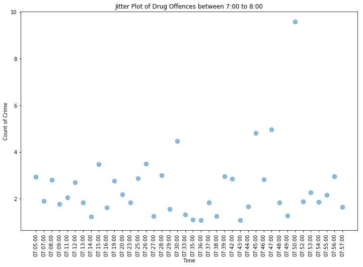

```python
plt.figure(figsize=(12,8))
## Plotting jitter plot
plt.scatter(range(six_months_data.shape[0]), [val + np.random.random() for val in six_months_data.Count], s=70, alpha=0.5)
plt.xticks(ticks=range(six_months_data.shape[0]), labels=[str(lab).split()[-1] for lab in six_months_data.index], rotation=90, );
plt.xlabel("Time");
plt.ylabel("Count of Crime")
plt.title('Jitter Plot of Drug Offences between 7:00 to 8:00');
```

> - Last time, we did lots bar-plots. Today, we'll play around with histograms (creating two crime-data based versions of the plot-type shown in DAOST **Figure 2-2**). I think the GPS data could be fun to see this way.
>   - This time, pick two crime-types with different geographical patterns **and** a suitable time-interval for each (you want between 1000 and 10000 points in your histogram)
>   - Then take the latitude part of the GPS coordinates for each crime and bin the latitudes so that you have around 50 bins across the city of SF. You can use your favorite method for binning. I like `numpy.histogram`. This function gives you the counts and then you do your own plotting.

```python
## Subsetting dataset to get only assault crimes data
assault_data = sf_police_df[sf_police_df['Category'] == 'ASSAULT']
assault_data = assault_data.dropna(subset=['X']) ## Dropping rows without latitude data
assault_data = assault_data.reset_index() ## Resetting index
print(assault_data.shape)
## Subsetting dataset to get only warrant crimes data
warrant_data = sf_police_df[sf_police_df['Category'] == 'WARRANTS']
warrant_data = warrant_data.dropna(subset=['X']) ## Dropping rows without latitude data
warrant_data = warrant_data.reset_index() ## Resetting index
print(warrant_data.shape)
```

```
(194694, 14)
(101379, 14)
```

```
Numpy Bins and Ranges [101365      0      0      0      0      0      0      0      0     14] [-122.51364206 -122.31227786 -122.11091365 -121.90954944 -121.70818524
 -121.50682103 -121.30545683 -121.10409262 -120.90272841 -120.70136421
 -120.5       ]
Matplotlib Bins and Ranges [1.01365e+05 0.00000e+00 0.00000e+00 0.00000e+00 0.00000e+00 0.00000e+00
 0.00000e+00 0.00000e+00 0.00000e+00 1.40000e+01] [-122.51364206 -122.31227786 -122.11091365 -121.90954944 -121.70818524
 -121.50682103 -121.30545683 -121.10409262 -120.90272841 -120.70136421
 -120.5       ]
```

[figure not shown]

```python
bin_values, bin_ranges = np.histogram(warrant_data['X']) ##Creating hist with numpy
##Plotting histogram using matplotlib
bins, ranges, objs = plt.hist(warrant_data['X'], bins=len(bin_values), color="tab:red", alpha=0.7)
plt.title("Histogram of Warrant Crime")
plt.xlabel("Latitude")

print('Numpy Bins and Ranges', bin_values, bin_ranges)
print('Matplotlib Bins and Ranges', bins, ranges)
```